# 第7回 習熟度確認と復習（1）：可視化・整形までの操作確認

行動計量学（行動科学分析法入門）

小野原 彩香

令和8年度

## 本日の流れ

1. **復習（前半）**：第2〜6回のポイントを確認
2. **習熟度確認テスト（後半）**：RStudio を使って課題に取り組む

## 復習：これまでの内容

### R・RStudioの基本（第2回）

```r
# 変数への代入
x <- 42
y <- c(1, 2, 3, 4, 5)

# 基本的な統計関数
mean(y)
```

```
## [1] 3
```

```r
sd(y)
```

```
## [1] 1.581139
```

### データの可視化 - ggplot2（第3・4回）

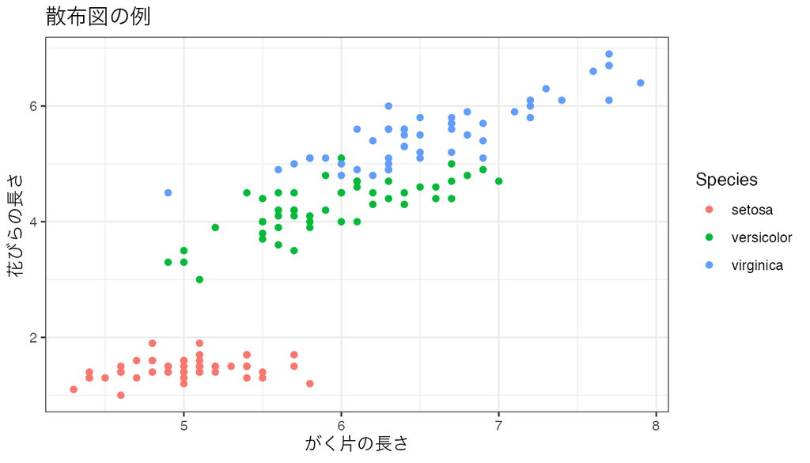

```r
# 散布図の基本
ggplot(data = iris, aes(x = Sepal.Length, y = Petal.Length, color = Species)) +
  geom_point() +
  labs(title = "散布図の例", x = "がく片の長さ", y = "花びらの長さ") +
  theme_bw()
```

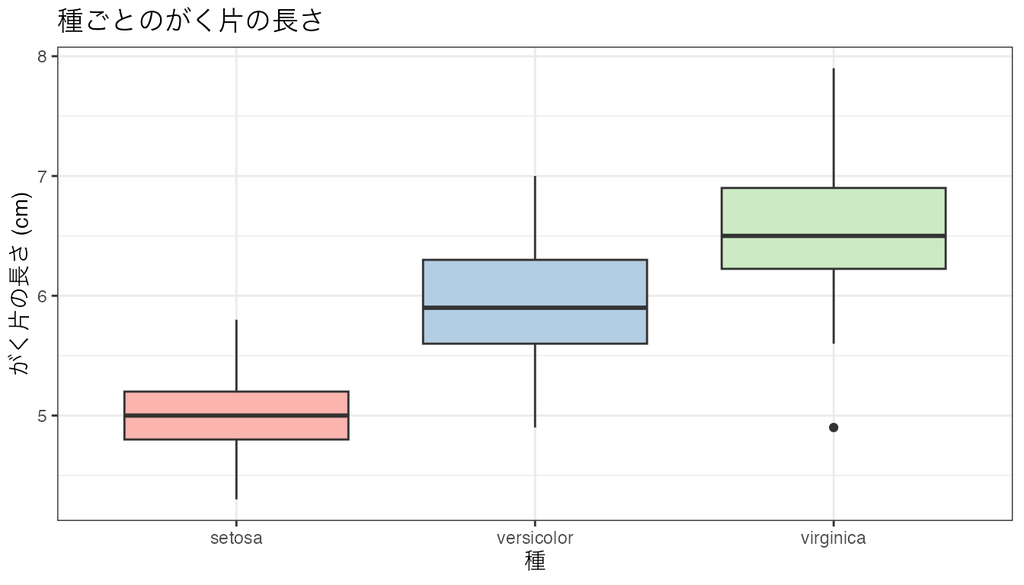

```r
# 箱ひげ図
ggplot(data = iris, aes(x = Species, y = Sepal.Length, fill = Species)) +
  geom_boxplot() +
  scale_fill_brewer(palette = "Pastel1") +
  labs(title = "種ごとのがく片の長さ", x = "種", y = "がく片の長さ (cm)") +
  theme_bw() +
  theme(legend.position = "none")
```

### データの加工 - dplyr（第5・6回）

```r
# filter + select + mutate + arrange の組み合わせ
iris |>
  filter(Species == "virginica") |>
  select(Sepal.Length, Sepal.Width, Petal.Length) |>
  mutate(sepal_ratio = Sepal.Length / Sepal.Width) |>
  arrange(desc(sepal_ratio)) |>
  head(5)
```

|  | Sepal.Length | Sepal.Width | Petal.Length | sepal_ratio |
| --- | --- | --- | --- | --- |
| 1 | 7.7 | 2.6 | 6.9 | 2.961538 |
| 2 | 7.7 | 2.8 | 6.7 | 2.750000 |
| 3 | 6.0 | 2.2 | 5.0 | 2.727273 |
| 4 | 6.7 | 2.5 | 5.8 | 2.680000 |
| 5 | 7.4 | 2.8 | 6.1 | 2.642857 |

```r
# group_by + summarise
iris |>
  group_by(Species) |>
  summarise(
    n    = n(),
    mean = mean(Petal.Length),
    sd   = sd(Petal.Length)
  )
```

| Species | n | mean | sd |
| --- | --- | --- | --- |
| setosa | 50 | 1.462 | 0.1736640 |
| versicolor | 50 | 4.260 | 0.4699110 |
| virginica | 50 | 5.552 | 0.5518947 |

## よくある間違いと対処法

| エラー | 原因 | 対処法 |
| --- | --- | --- |
| `could not find function` | パッケージを読み込んでいない | `library(tidyverse)` を実行 |
| `object not found` | 変数名が間違っている | スペル・大文字小文字を確認 |
| `unexpected ')'` | 括弧が合っていない | 括弧の数をチェック |
| グラフが表示されない | データが空など | `str()` / `head()` でデータを確認 |
| `NA` が返ってくる | 欠損値が含まれている | `na.rm = TRUE` を追加 |

## 習熟度確認テスト（第1回）

**問題は授業当日に配布します。**

この回は前半が復習，後半が習熟度確認テストです。 テストは RStudio で実際にデータを分析し，作成した `.R` スクリプトを提出する形式で行います。 出題範囲は，上の復習部分で扱った内容です。

> 問題と解答例は，**テスト実施後にこのページへ掲載します。**

## 提出方法

- 作成した R スクリプト（`.R` ファイル）を保存する
- ファイル名：`習熟度確認1_学籍番号.R`
- 提出先：授業内で案内します

## 本日のまとめ

- 第2〜6回の内容（Rの基本操作・可視化・加工）を復習した
- 習熟度確認テストで `filter()`, `select()`, `mutate()`, `arrange()`, `group_by()`, `summarise()`, `ggplot2` の操作を確認した

## 次回の予告

次回（第8回）から**推測統計**に入ります。

- 相関分析と散布図
- 2変数の関係を数値で表す「相関係数」とは？

教科書の相関分析に関する章を読んでおきましょう。